# Project: Identify Customer Segments

#### Discussion 1.1.2: Assess Missing Data in Each Column

After reviewing the Histogram plot, there's gap over the 200000 mark. I was debating between droping all columns greater than 200000 nulls or only the top 4 columns(5%) of the most null valued columns (columns with * are the top 4).

AGER_TYP* refers to the type of elder they are. Cultural, passive, or experience driven elder. If I was specifically trying to gain an outlook on that generation, I'd drop the rows without this data.

GEBURTSJAHR refers to the year of birth.

TITEL_KZ* if they have a formal address such as Doctor or Professor.

ALTER_HH is the birthdate of the head of household

KK_KUNDENTYP* the frequentcy of the shopping in the last 12 months.

KBA05_BAUMAX* is the building type they live in.

I ultimately decided to drop all columns listed. Ways to identify age is referenced in other areas of the dataframe, therefore, GEBURTSJAHR & ALTER_HH being dropped seemed OK.

#### Step 1.1.3: Assess Missing Data in Each Row

Now, you'll perform a similar assessment for the rows of the dataset. How much data is missing in each row? As with the columns, you should see some groups of points that have a very different numbers of missing values. Divide the data into two subsets: one for data points that are above some threshold for missing values, and a second subset for points below that threshold.

In order to know what to do with the outlier rows, we should see if the distribution of data values on columns that are not missing data (or are missing very little data) are similar or different between the two groups. Select at least five of these columns and compare the distribution of values.

- You can use seaborn's [`countplot()`](https://seaborn.pydata.org/generated/seaborn.countplot.html) function to create a bar chart of code frequencies and matplotlib's [`subplot()`](https://matplotlib.org/api/_as_gen/matplotlib.pyplot.subplot.html) function to put bar charts for the two subplots side by side.
- To reduce repeated code, you might want to write a function that can perform this comparison, taking as one of its arguments a column to be compared.

Depending on what you observe in your comparison, this will have implications on how you approach your conclusions later in the analysis. If the distributions of non-missing features look similar between the data with many missing values and the data with few or no missing values, then we could argue that simply dropping those points from the analysis won't present a major issue. On the other hand, if the data with many missing values looks very different from the data with few or no missing values, then we should make a note on those data as special. We'll revisit these data later on. **Either way, you should continue your analysis for now using just the subset of the data with few or no missing values.**

```python
# How much data is missing in each row of the dataset?
RowReview = azCopy.isnull().sum(axis=1) #total NaN by row
print((RowReview==0).sum())
print((RowReview>0).sum())
```

```
623209
268012
```

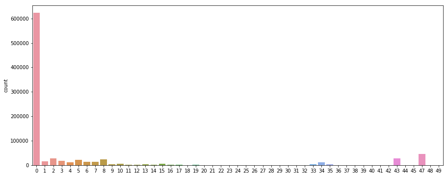

```python
plt.figure(figsize=(15,6))
sns.countplot(RowReview)
```

```python
# Write code to divide the data into two subsets based on the number of missing
# values in each row.
dropNaN = []
noNaN = []
for idx, val in enumerate(RowReview):
    if val == 0: #if none of the columsn in that row has an NaN value,
        noNaN.append(idx) #append it to this list.
    else:
        dropNaN.append(idx) #all others will append here.

azComplete = azCopy.drop(dropNaN) #this will create a new DataFrame without any NaN
azNaN = azCopy.drop(noNaN) #this will create a new DataFrame with the remaining rows

print(azComplete.shape)
print(azNaN.shape)
```

```
(623209, 79)
(268012, 79)
```

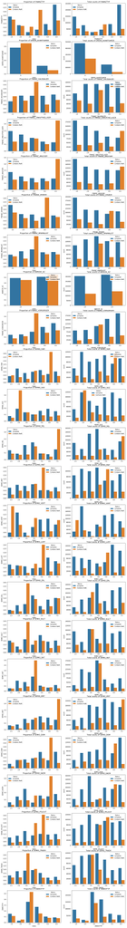

```python
# Compare the distribution of values for at least five columns where there are
# no or few missing values, between the two subsets.
i=0
fig, axes = plt.subplots(24, 2, figsize=(15, 120))

#Creates the DF for the graphs on the right based on Counts
Plotting2 = []
plot3 = azComplete[zeroColumns].reset_index()
plot3['Status'] = 'Complete'
plot4 = azNaN[zeroColumns].reset_index()
plot4['Status'] = 'Contains NaN'
Plotting2 = pd.concat([plot3, plot4], sort=False)

for column in zeroColumns:

    Plotting = []  #Creates the DF for the graphs on the left based on proportion
    plot1 = azComplete[column].value_counts(normalize=True).reset_index().sort_values('index')
    plot1['Status'] = 'Complete'
    plot2 = azNaN[column].value_counts(normalize=True).reset_index().sort_values('index')
    plot2['Status'] = 'Contains NaN'
    Plotting = pd.concat([plot1, plot2], sort=False)

    sns.barplot(ax=axes[i, 0], data=Plotting, x='index', y=column, hue='Status').set(title=f"Proportion of {column}") #Proportion
    sns.countplot(ax=axes[i, 1], data=Plotting2, x=column, hue='Status').set(title=f"Total counts of {column}")  #Count

    i+=1
```

#### Discussion 1.1.3: Assess Missing Data in Each Row

Almost 70%, 623,209 rows, of the dataframe is complete data.

Unfortunately, for these columns, the Complete data vs Contains NaN are not proportional when compared to each other. In reviewing the first 2, FINANSTYP may be quite beneficial, but quite unproporational to each other. Dropping the orange rows would misrepresent "4 - Be Prepared" and "6 - inconspicuous". However, there are many other columns related to finances that this porportional difference may not sway the results as much (Although, there are a few Finance columns on this list). GREEN*AVANTAGARDE looks proportional between the 2 dataframes, so dropping the Contains NaN rows, shouldn't be as impactful. Semio*--- are common columns listed here also. These represent the mind type, all of which have some null values.

After researching ways to address NaNs, will be dropping these rows. The following options were reviewed:

- Dropping Row: Disadvantage is losing all data that is available for that row. As noted above, some columns were unporportional between complete and Containing NaNs.
- Imputing: The values are filled in with Mean, Median, or Most Frequent, all felt ficticouls and will skew the data already available.
- KNNImputing: KNN imputing takes the K-nearest neighbors and finds an average. I felt this would be the best option to attempt to keep the data balanced. Unfortunately, KNNImputing is a V0.22. Currently from sklearn.preprocessing import sklearn : sklearn.**version** '0.19.1'

Therefore, I will drop rows containing any NaN values.

### Step 1.2: Select and Re-Encode Features

Checking for missing data isn't the only way in which you can prepare a dataset for analysis. Since the unsupervised learning techniques to be used will only work on data that is encoded numerically, you need to make a few encoding changes or additional assumptions to be able to make progress. In addition, while almost all of the values in the dataset are encoded using numbers, not all of them represent numeric values. Check the third column of the feature summary (`feat_info`) for a summary of types of measurement.

- For numeric and interval data, these features can be kept without changes.
- Most of the variables in the dataset are ordinal in nature. While ordinal values may technically be non-linear in spacing, make the simplifying assumption that the ordinal variables can be treated as being interval in nature (that is, kept without any changes).
- Special handling may be necessary for the remaining two variable types: categorical, and 'mixed'.

In the first two parts of this sub-step, you will perform an investigation of the categorical and mixed-type features and make a decision on each of them, whether you will keep, drop, or re-encode each. Then, in the last part, you will create a new data frame with only the selected and engineered columns.

Data wrangling is often the trickiest part of the data analysis process, and there's a lot of it to be done here. But stick with it: once you're done with this step, you'll be ready to get to the machine learning parts of the project!

```python
# How many features are there of each data type?
feat_info.type.value_counts()
```

```
ordinal        49
categorical    21
mixed           7
numeric         7
interval        1
Name: type, dtype: int64
```

```python
categoricalCols = feat_info.query('type == "categorical"')['attribute'].tolist()
feat_info.query('attribute == @categoricalCols')
```

|  | attribute | information_level | type | missing_or_unknown |
| --- | --- | --- | --- | --- |
| 0 | AGER_TYP | person | categorical | [-1,0] |
| 2 | ANREDE_KZ | person | categorical | [-1,0] |
| 3 | CJT_GESAMTTYP | person | categorical | [0] |
| 10 | FINANZTYP | person | categorical | [-1] |
| 12 | GFK_URLAUBERTYP | person | categorical | [] |
| 13 | GREEN_AVANTGARDE | person | categorical | [] |
| 17 | LP_FAMILIE_FEIN | person | categorical | [0] |
| 18 | LP_FAMILIE_GROB | person | categorical | [0] |
| 19 | LP_STATUS_FEIN | person | categorical | [0] |
| 20 | LP_STATUS_GROB | person | categorical | [0] |
| 21 | NATIONALITAET_KZ | person | categorical | [-1,0] |
| 38 | SHOPPER_TYP | person | categorical | [-1] |
| 39 | SOHO_KZ | person | categorical | [-1] |
| 40 | TITEL_KZ | person | categorical | [-1,0] |
| 41 | VERS_TYP | person | categorical | [-1] |
| 42 | ZABEOTYP | person | categorical | [-1,9] |
| 47 | KK_KUNDENTYP | household | categorical | [-1] |
| 52 | GEBAEUDETYP | building | categorical | [-1,0] |
| 55 | OST_WEST_KZ | building | categorical | [-1] |
| 57 | CAMEO_DEUG_2015 | microcell_rr4 | categorical | [-1,X] |
| 58 | CAMEO_DEU_2015 | microcell_rr4 | categorical | [XX] |

```python
#I wanted to see what was unique and special about these columns.
for column in categoricalCols:
    try:
        print(column,'\t', azComplete[column].isnull().sum(),'\t', azComplete[column].unique())
    except KeyError:  #These columns were previously dropped from the azComplete Dataframe.
          print(f'Column {column} was dropped from Dataframe')
```

```
Column AGER_TYP was dropped from Dataframe
ANREDE_KZ 	 0 	 [ 2.  1.]
CJT_GESAMTTYP 	 0 	 [ 5.  3.  2.  4.  1.  6.]
FINANZTYP 	 0 	 [ 1.  5.  2.  4.  6.  3.]
GFK_URLAUBERTYP 	 0 	 [ 10.   5.   1.  12.   9.   3.   8.  11.   4.   7.   6.   2.]
GREEN_AVANTGARDE 	 0 	 [0 1]
LP_FAMILIE_FEIN 	 0 	 [  5.   1.  10.   2.   7.  11.   8.   4.   6.   9.   3.]
LP_FAMILIE_GROB 	 0 	 [ 3.  1.  5.  2.  4.]
LP_STATUS_FEIN 	 0 	 [  2.   3.   4.   1.  10.   9.   5.   6.   7.   8.]
LP_STATUS_GROB 	 0 	 [ 1.  2.  5.  4.  3.]
NATIONALITAET_KZ 	 0 	 [ 1.  2.  3.]
SHOPPER_TYP 	 0 	 [ 3.  2.  0.  1.]
SOHO_KZ 	 0 	 [ 1.  0.]
Column TITEL_KZ was dropped from Dataframe
VERS_TYP 	 0 	 [ 2.  1.]
ZABEOTYP 	 0 	 [ 5.  4.  1.  6.  3.  2.]
Column KK_KUNDENTYP was dropped from Dataframe
GEBAEUDETYP 	 0 	 [ 8.  1.  3.  5.]
OST_WEST_KZ 	 0 	 ['W' 'O']
CAMEO_DEUG_2015 	 0 	 ['8' '4' '6' '2' '1' '9' '5' '7' '3']
CAMEO_DEU_2015 	 0 	 ['8A' '4C' '6B' '8C' '4A' '2D' '1A' '1E' '9D' '5D' '9E' '9B' '1B' '8B' '7A'
 '3D' '4E' '3C' '5A' '7B' '9A' '6E' '6D' '2C' '5C' '9C' '7D' '5E' '1D' '8D'
 '6C' '5B' '7C' '4D' '3A' '2B' '7E' '4B' '2A' '3B' '6F' '5F' '1C' '6A']
```

#### Step 1.2.1: Re-Encode Categorical Features

For categorical data, you would ordinarily need to encode the levels as dummy variables. Depending on the number of categories, perform one of the following:

- For binary (two-level) categoricals that take numeric values, you can keep them without needing to do anything.
- There is one binary variable that takes on non-numeric values. For this one, you need to re-encode the values as numbers or create a dummy variable.
- For multi-level categoricals (three or more values), you can choose to encode the values using multiple dummy variables (e.g. via [OneHotEncoder](http://scikit-learn.org/stable/modules/generated/sklearn.preprocessing.OneHotEncoder.html)), or (to keep things straightforward) just drop them from the analysis. As always, document your choices in the Discussion section.

```python
# Assess categorical variables: which are binary, which are multi-level, and
# which one needs to be re-encoded?


#After reviewing the above columns in the Data_Dictionary.MD, they will be updated as follows
#Binary Numerics will be convert to numeric terms based on the numbers provided OR 1/2 in the instance of 'OST_WEST_KZ'
Bnumerics = ['ANREDE_KZ', 'GREEN_AVANTGARDE',  'SOHO_KZ', 'VERS_TYP', 'OST_WEST_KZ']
for column in Bnumerics:
    try:
        azComplete[column] = azComplete[column].astype(int)
    except ValueError:
        azComplete[column] = azComplete[column].map({'W':0, 'O':1}).astype(int)


#Multi-level Numerics will be convert to numeric terms based on the numbers provided OR 1/2 in the instance of 'OST_WEST_KZ'
MLnumerics = ['SHOPPER_TYP', 'CJT_GESAMTTYP', 'FINANZTYP', 'GFK_URLAUBERTYP', 'ZABEOTYP', 'LP_STATUS_FEIN', 'LP_FAMILIE_FEIN', 'GEBAEUDETYP']

for column in MLnumerics:
    azComplete[column] = azComplete[column].astype(int)
```

```python
# Re-encode categorical variable(s) to be kept in the analysis.

#The following will be dropped. I don't feel the information retained will be sufficient OR is duplicated with a more fine detail in an above column.
drops = ['NATIONALITAET_KZ', 'LP_FAMILIE_GROB', 'LP_STATUS_GROB', 'CAMEO_DEUG_2015', 'CAMEO_DEU_2015','MIN_GEBAEUDEJAHR', 'KBA13_ANZAHL_PKW', 'ANZ_HAUSHALTE_AKTIV']
azComplete = azComplete.drop(columns=drops)
```

#### Step 1.2.2: Engineer Mixed-Type Features

There are a handful of features that are marked as "mixed" in the feature summary that require special treatment in order to be included in the analysis. There are two in particular that deserve attention; the handling of the rest are up to your own choices:

- "PRAEGENDE_JUGENDJAHRE" combines information on three dimensions: generation by decade, movement (mainstream vs. avantgarde), and nation (east vs. west). While there aren't enough levels to disentangle east from west, you should create two new variables to capture the other two dimensions: an interval-type variable for decade, and a binary variable for movement.
- "CAMEO_INTL_2015" combines information on two axes: wealth and life stage. Break up the two-digit codes by their 'tens'-place and 'ones'-place digits into two new ordinal variables (which, for the purposes of this project, is equivalent to just treating them as their raw numeric values).
- If you decide to keep or engineer new features around the other mixed-type features, make sure you note your steps in the Discussion section.

Be sure to check `Data_Dictionary.md` for the details needed to finish these tasks.

```python
mixedCols = feat_info.query('type == "mixed"')['attribute'].tolist()
feat_info.query('attribute == @mixedCols')
```

|  | attribute | information_level | type | missing_or_unknown |
| --- | --- | --- | --- | --- |
| 15 | LP_LEBENSPHASE_FEIN | person | mixed | [0] |
| 16 | LP_LEBENSPHASE_GROB | person | mixed | [0] |
| 22 | PRAEGENDE_JUGENDJAHRE | person | mixed | [-1,0] |
| 56 | WOHNLAGE | building | mixed | [-1] |
| 59 | CAMEO_INTL_2015 | microcell_rr4 | mixed | [-1,XX] |
| 64 | KBA05_BAUMAX | microcell_rr3 | mixed | [-1,0] |
| 79 | PLZ8_BAUMAX | macrocell_plz8 | mixed | [-1,0] |

```python
#I wanted to see what was unique and special about these columns.
for column in mixedCols:
    try:
        print(column,'\t', azComplete[column].isnull().sum(),'\t', azComplete[column].unique())
    except KeyError:  #These columns were previously dropped from the azComplete Dataframe.
          print(f'Column {column} was dropped from Dataframe')
```

```
LP_LEBENSPHASE_FEIN 	 0 	 [ 21.   3.  32.   8.   2.   5.  10.   4.   6.  20.   1.  25.  18.  31.  38.
  30.   7.  22.  14.  35.  29.  24.  37.  12.  39.  36.  13.   9.  34.  26.
  33.  15.  11.  40.  16.  19.  23.  27.  28.  17.]
LP_LEBENSPHASE_GROB 	 0 	 [  6.   1.  10.   2.   3.   5.   7.  12.   9.   4.  11.   8.]
PRAEGENDE_JUGENDJAHRE 	 0 	 [ 14.  15.   8.   3.  10.  11.   9.   5.   4.   2.   6.   1.  12.  13.   7.]
WOHNLAGE 	 0 	 [ 4.  2.  3.  7.  5.  1.  8.  0.]
CAMEO_INTL_2015 	 0 	 ['51' '24' '43' '54' '22' '14' '13' '15' '34' '55' '41' '25' '31' '52' '45'
 '35' '33' '44' '32' '23' '12']
Column KBA05_BAUMAX was dropped from Dataframe
PLZ8_BAUMAX 	 0 	 [ 1.  2.  4.  5.  3.]
```

```python
#The following will be converted to multilevel numericals
MLnumerics = ['LP_LEBENSPHASE_FEIN', 'WOHNLAGE', 'PLZ8_BAUMAX', ]
for column in MLnumerics:
    azComplete[column] = azComplete[column].astype(int)

#The following will be dropped. I don't feel the information retained will be sufficient OR is duplicated with a more fine detail in an above column.
drops = ['LP_LEBENSPHASE_GROB' ]
azComplete = azComplete.drop(columns=drops)
```

```python
#Opening the Data_dictionary, I'm going going to find the text regarding the description of "PRAEGENDE_JUGENDJAHRE"
with open('Data_Dictionary.md', 'r') as DataFile:
    text = DataFile.read()
    start = text.find("PRAEGENDE_JUGENDJAHRE")
    start = text.find('-', start)
    end = text.find('###', start)
    DataDescribe = text[start:end]

#Next, Creating a list with the information in the Data_Dictionary example for line 1:
#1: 40s - war years (Mainstream, E+W)   : List states 1, 40(1940's), 1 (for Mainstream), 3(for E+W)
i=-1
MA = {}
EW = {}
MAD = {'Mainstream':0, 'Avantgarde':1}
EWD = {'E':0,'W':1,'E+W':2}
for line in DataDescribe.split("\n-"):
    start = line.find("(")
    end = line.find(",")
    ma = line[start+1:end]
    start = end
    end = line.find(")")
    ew = line[start+2:end]
    if i>0:
        MA[i] = MAD[ma]
        EW[i] = EWD[ew]
    i+=1
```

```python
# Investigate "PRAEGENDE_JUGENDJAHRE" and engineer two new variables.
azComplete['MAIN_AVA'] = azComplete['PRAEGENDE_JUGENDJAHRE'].map(MA)
azComplete['E_W'] = azComplete['PRAEGENDE_JUGENDJAHRE'].map(EW)
azComplete = azComplete.drop(columns='PRAEGENDE_JUGENDJAHRE')
azComplete.head()
```

|  | ALTERSKATEGORIE_GROB | ANREDE_KZ | CJT_GESAMTTYP | FINANZ_MINIMALIST | FINANZ_SPARER | FINANZ_VORSORGER | FINANZ_ANLEGER | FINANZ_UNAUFFAELLIGER | FINANZ_HAUSBAUER | FINANZTYP | ... | PLZ8_ANTG3 | PLZ8_ANTG4 | PLZ8_BAUMAX | PLZ8_HHZ | PLZ8_GBZ | ARBEIT | ORTSGR_KLS9 | RELAT_AB | MAIN_AVA | E_W |
| --- | --- | --- | --- | --- | --- | --- | --- | --- | --- | --- | --- | --- | --- | --- | --- | --- | --- | --- | --- | --- | --- |
| 1 | 1.0 | 2 | 5 | 1.0 | 5.0 | 2.0 | 5.0 | 4.0 | 5.0 | 1 | ... | 2.0 | 1.0 | 1 | 5.0 | 4.0 | 3.0 | 5.0 | 4.0 | 0 | 2 |
| 2 | 3.0 | 2 | 3 | 1.0 | 4.0 | 1.0 | 2.0 | 3.0 | 5.0 | 1 | ... | 1.0 | 0.0 | 1 | 4.0 | 4.0 | 3.0 | 5.0 | 2.0 | 1 | 2 |
| 4 | 3.0 | 1 | 5 | 4.0 | 3.0 | 4.0 | 1.0 | 3.0 | 2.0 | 5 | ... | 2.0 | 1.0 | 2 | 3.0 | 3.0 | 4.0 | 6.0 | 5.0 | 0 | 2 |
| 5 | 1.0 | 2 | 2 | 3.0 | 1.0 | 5.0 | 2.0 | 2.0 | 5.0 | 2 | ... | 1.0 | 1.0 | 1 | 5.0 | 5.0 | 2.0 | 3.0 | 3.0 | 0 | 2 |
| 6 | 2.0 | 2 | 5 | 1.0 | 5.0 | 1.0 | 5.0 | 4.0 | 3.0 | 4 | ... | 1.0 | 0.0 | 1 | 5.0 | 5.0 | 4.0 | 6.0 | 3.0 | 0 | 1 |

5 rows × 71 columns

```python
# Investigate "CAMEO_INTL_2015" and engineer two new variables.
#Per the Data_Dictionary, if the number begins with 1 = Wealthy, 4=Less Affluent. If the number ends 1=Pre-Family, ends 5=Elders.
#Therefore, I'm going to split this column into 2 based on this number.
azComplete['WEALTH']=azComplete.CAMEO_INTL_2015.str[0].astype(int)
azComplete['LIFESTYLE']=azComplete.CAMEO_INTL_2015.str[1].astype(int)
azComplete = azComplete.drop(columns='CAMEO_INTL_2015')
azComplete.head()
```

|  | ALTERSKATEGORIE_GROB | ANREDE_KZ | CJT_GESAMTTYP | FINANZ_MINIMALIST | FINANZ_SPARER | FINANZ_VORSORGER | FINANZ_ANLEGER | FINANZ_UNAUFFAELLIGER | FINANZ_HAUSBAUER | FINANZTYP | ... | PLZ8_BAUMAX | PLZ8_HHZ | PLZ8_GBZ | ARBEIT | ORTSGR_KLS9 | RELAT_AB | MAIN_AVA | E_W | WEALTH | LIFESTYLE |
| --- | --- | --- | --- | --- | --- | --- | --- | --- | --- | --- | --- | --- | --- | --- | --- | --- | --- | --- | --- | --- | --- |
| 1 | 1.0 | 2 | 5 | 1.0 | 5.0 | 2.0 | 5.0 | 4.0 | 5.0 | 1 | ... | 1 | 5.0 | 4.0 | 3.0 | 5.0 | 4.0 | 0 | 2 | 5 | 1 |
| 2 | 3.0 | 2 | 3 | 1.0 | 4.0 | 1.0 | 2.0 | 3.0 | 5.0 | 1 | ... | 1 | 4.0 | 4.0 | 3.0 | 5.0 | 2.0 | 1 | 2 | 2 | 4 |
| 4 | 3.0 | 1 | 5 | 4.0 | 3.0 | 4.0 | 1.0 | 3.0 | 2.0 | 5 | ... | 2 | 3.0 | 3.0 | 4.0 | 6.0 | 5.0 | 0 | 2 | 4 | 3 |
| 5 | 1.0 | 2 | 2 | 3.0 | 1.0 | 5.0 | 2.0 | 2.0 | 5.0 | 2 | ... | 1 | 5.0 | 5.0 | 2.0 | 3.0 | 3.0 | 0 | 2 | 5 | 4 |
| 6 | 2.0 | 2 | 5 | 1.0 | 5.0 | 1.0 | 5.0 | 4.0 | 3.0 | 4 | ... | 1 | 5.0 | 5.0 | 4.0 | 6.0 | 3.0 | 0 | 1 | 2 | 2 |

5 rows × 72 columns

#### Discussion 1.2.2: Engineer Mixed-Type Features

Columns ending "Fein" are more fine detail for columns ending "Grob", therefore, if they were on the list, I dropped these colmns. The CAMEO_INTL_2015 mapped that the first index fit the Wealth and the 2nd indext fit the Lifestyle, so I was able to split the string.

#### Step 1.2.3: Complete Feature Selection

In order to finish this step up, you need to make sure that your data frame now only has the columns that you want to keep. To summarize, the dataframe should consist of the following:

- All numeric, interval, and ordinal type columns from the original dataset.
- Binary categorical features (all numerically-encoded).
- Engineered features from other multi-level categorical features and mixed features.

Make sure that for any new columns that you have engineered, that you've excluded the original columns from the final dataset. Otherwise, their values will interfere with the analysis later on the project. For example, you should not keep "PRAEGENDE_JUGENDJAHRE", since its values won't be useful for the algorithm: only the values derived from it in the engineered features you created should be retained. As a reminder, your data should only be from **the subset with few or no missing values**.

```python
# If there are other re-engineering tasks you need to perform, make sure you
# take care of them here. (Dealing with missing data will come in step 2.1.)
```

```python
# Do whatever you need to in order to ensure that the dataframe only contains
# the columns that should be passed to the algorithm functions.
CheckMate = ['ALTERSKATEGORIE_GROB', 'ANREDE_KZ', 'CJT_GESAMTTYP',
       'FINANZ_MINIMALIST', 'FINANZ_SPARER', 'FINANZ_VORSORGER',
       'FINANZ_ANLEGER', 'FINANZ_UNAUFFAELLIGER', 'FINANZ_HAUSBAUER',
       'FINANZTYP', 'GFK_URLAUBERTYP', 'GREEN_AVANTGARDE', 'HEALTH_TYP',
       'LP_LEBENSPHASE_FEIN', 'LP_FAMILIE_FEIN', 'LP_STATUS_FEIN',
       'RETOURTYP_BK_S', 'SEMIO_SOZ', 'SEMIO_FAM', 'SEMIO_REL', 'SEMIO_MAT',
       'SEMIO_VERT', 'SEMIO_LUST', 'SEMIO_ERL', 'SEMIO_KULT', 'SEMIO_RAT',
       'SEMIO_KRIT', 'SEMIO_DOM', 'SEMIO_KAEM', 'SEMIO_PFLICHT', 'SEMIO_TRADV',
       'SHOPPER_TYP', 'SOHO_KZ', 'VERS_TYP', 'ZABEOTYP', 'ANZ_PERSONEN',
       'ANZ_TITEL', 'HH_EINKOMMEN_SCORE', 'W_KEIT_KIND_HH', 'WOHNDAUER_2008',
       'ANZ_HH_TITEL', 'GEBAEUDETYP', 'KONSUMNAEHE',
       'OST_WEST_KZ', 'WOHNLAGE', 'KBA05_ANTG1',
       'KBA05_ANTG2', 'KBA05_ANTG3', 'KBA05_ANTG4', 'KBA05_GBZ', 'BALLRAUM',
       'EWDICHTE', 'INNENSTADT', 'GEBAEUDETYP_RASTER', 'KKK', 'MOBI_REGIO',
       'ONLINE_AFFINITAET', 'REGIOTYP',  'PLZ8_ANTG1',
       'PLZ8_ANTG2', 'PLZ8_ANTG3', 'PLZ8_ANTG4', 'PLZ8_BAUMAX', 'PLZ8_HHZ',
       'PLZ8_GBZ', 'ARBEIT', 'ORTSGR_KLS9', 'RELAT_AB', 'MAIN_AVA', 'E_W',
       'WEALTH', 'LIFESTYLE']
endedColumns = azComplete.columns.tolist()
endedColumns == CheckMate
```

```
True
```

```python
azComplete.info()
```

```
<class 'pandas.core.frame.DataFrame'>
Int64Index: 623209 entries, 1 to 891220
Data columns (total 72 columns):
ALTERSKATEGORIE_GROB     623209 non-null float64
ANREDE_KZ                623209 non-null int64
CJT_GESAMTTYP            623209 non-null int64
FINANZ_MINIMALIST        623209 non-null float64
FINANZ_SPARER            623209 non-null float64
FINANZ_VORSORGER         623209 non-null float64
FINANZ_ANLEGER           623209 non-null float64
FINANZ_UNAUFFAELLIGER    623209 non-null float64
FINANZ_HAUSBAUER         623209 non-null float64
FINANZTYP                623209 non-null int64
GFK_URLAUBERTYP          623209 non-null int64
GREEN_AVANTGARDE         623209 non-null int64
HEALTH_TYP               623209 non-null float64
LP_LEBENSPHASE_FEIN      623209 non-null int64
LP_FAMILIE_FEIN          623209 non-null int64
LP_STATUS_FEIN           623209 non-null int64
RETOURTYP_BK_S           623209 non-null float64
SEMIO_SOZ                623209 non-null float64
SEMIO_FAM                623209 non-null float64
SEMIO_REL                623209 non-null float64
SEMIO_MAT                623209 non-null float64
SEMIO_VERT               623209 non-null float64
SEMIO_LUST               623209 non-null float64
SEMIO_ERL                623209 non-null float64
SEMIO_KULT               623209 non-null float64
SEMIO_RAT                623209 non-null float64
SEMIO_KRIT               623209 non-null float64
SEMIO_DOM                623209 non-null float64
SEMIO_KAEM               623209 non-null float64
SEMIO_PFLICHT            623209 non-null float64
SEMIO_TRADV              623209 non-null float64
SHOPPER_TYP              623209 non-null int64
SOHO_KZ                  623209 non-null int64
VERS_TYP                 623209 non-null int64
ZABEOTYP                 623209 non-null int64
ANZ_PERSONEN             623209 non-null float64
ANZ_TITEL                623209 non-null float64
```

[output cut: 22 more lines]

```
PLZ8_ANTG2               623209 non-null float64
PLZ8_ANTG3               623209 non-null float64
PLZ8_ANTG4               623209 non-null float64
PLZ8_BAUMAX              623209 non-null int64
PLZ8_HHZ                 623209 non-null float64
PLZ8_GBZ                 623209 non-null float64
ARBEIT                   623209 non-null float64
ORTSGR_KLS9              623209 non-null float64
RELAT_AB                 623209 non-null float64
MAIN_AVA                 623209 non-null int64
E_W                      623209 non-null int64
WEALTH                   623209 non-null int64
LIFESTYLE                623209 non-null int64
dtypes: float64(52), int64(20)
memory usage: 347.1 MB
```

### Step 1.3: Create a Cleaning Function

Even though you've finished cleaning up the general population demographics data, it's important to look ahead to the future and realize that you'll need to perform the same cleaning steps on the customer demographics data. In this substep, complete the function below to execute the main feature selection, encoding, and re-engineering steps you performed above. Then, when it comes to looking at the customer data in Step 3, you can just run this function on that DataFrame to get the trimmed dataset in a single step.

```python
#Cleaning_Function Cell
def feature_clean(df):
    feat_info = pd.read_csv('AZDIAS_Feature_Summary.csv', sep=';')

    for index, row in feat_info.iterrows():
        ColsNames = row['attribute'] #Column name to update
        myString = row['missing_or_unknown'] #Becomes array of numbers that mean missing or unknown.
        if len(myString)>2:
            MissingArray = np.array(myString[1:-1].split(","))
            if len(MissingArray)>0:
                for i in MissingArray:
                    Keylist = []
                    try:
                        df.loc[df[ColsNames] == float(i), ColsNames] = np.nan
                    except ValueError:
                        df.loc[df[ColsNames] == i, ColsNames] = np.nan
                    except KeyError:
                        Keylist.extend(ColsNames)

    return df

def drop_columns(df):
    #Drop columns from DF that are never formatted/needed.
    df = df.drop(columns=['AGER_TYP', 'GEBURTSJAHR', 'TITEL_KZ', 'ALTER_HH', 'KK_KUNDENTYP',
                'KBA05_BAUMAX','NATIONALITAET_KZ', 'LP_FAMILIE_GROB', 'LP_STATUS_GROB', 'CAMEO_DEUG_2015', 'CAMEO_DEU_2015',
                'LP_LEBENSPHASE_GROB','MIN_GEBAEUDEJAHR', 'KBA13_ANZAHL_PKW', 'ANZ_HAUSHALTE_AKTIV'])
    return df

def to_numerics(df):
    #Convert all needed columns to integers
    toNumerics = ['ANREDE_KZ', 'GREEN_AVANTGARDE',  'SOHO_KZ', 'VERS_TYP', 'OST_WEST_KZ','SHOPPER_TYP', 'CJT_GESAMTTYP', 'FINANZTYP', 'GFK_URLAUBERTYP', 'ZABEOTYP', 'LP_STATUS_FEIN',
                  'LP_FAMILIE_FEIN', 'GEBAEUDETYP','LP_LEBENSPHASE_FEIN', 'WOHNLAGE', 'PLZ8_BAUMAX']

    for column in toNumerics:
        Valuelist = []
        try:
            df[column] = df[column].astype(float)
        except ValueError:
            df[column] = df[column].map({'W':0, 'O':1}).astype(float)

    return df


def SpecialMap(df):
    #These columns require special mapping based on Data_Dictionary
    MA = {1: 0, 2: 1, 3: 0, 4: 1, 5: 0, 6: 1, 7: 1, 8: 0, 9: 1, 10: 0, 11: 1, 12: 0, 13: 1, 14: 0, 15: 1}
    EW = {1: 2, 2: 2, 3: 2, 4: 2, 5: 2, 6: 1, 7: 0, 8: 2, 9: 2, 10: 1, 11: 1, 12: 0, 13: 0, 14: 2, 15: 2}

    df['MAIN_AVA']=df['PRAEGENDE_JUGENDJAHRE'].map(MA)
    df['E_W']=df['PRAEGENDE_JUGENDJAHRE'].map(EW)
    df['WEALTH']=df.CAMEO_INTL_2015.str[0].astype(float)
    df['LIFESTYLE']=df.CAMEO_INTL_2015.str[1].astype(float)

    #Any column remapped needs to be dropped
    df = df.drop(columns=['PRAEGENDE_JUGENDJAHRE','CAMEO_INTL_2015'])

    return df

def drop_NANrows(df):
    #Any row that has a NaN will be dropped
    dropRows = df.isnull().sum(axis=1)
    dropNANs = []
    for idx, val in enumerate(dropRows):
        if val != 0: #if none of the columns in that row has an NaN value,
            dropNANs.append(idx) #append it to this list.
    df = df.drop(dropNANs) #this will create a new DataFrame without any NaN
    print(f'Number of rows dropped: {len(dropNANs)}')
    return df


def verifyCompletion(df):
    CheckMate = ['ALTERSKATEGORIE_GROB', 'ANREDE_KZ', 'CJT_GESAMTTYP', 'FINANZ_MINIMALIST', 'FINANZ_SPARER', 'FINANZ_VORSORGER',
     'FINANZ_ANLEGER', 'FINANZ_UNAUFFAELLIGER', 'FINANZ_HAUSBAUER', 'FINANZTYP', 'GFK_URLAUBERTYP', 'GREEN_AVANTGARDE',
     'HEALTH_TYP', 'LP_LEBENSPHASE_FEIN', 'LP_FAMILIE_FEIN', 'LP_STATUS_FEIN', 'RETOURTYP_BK_S', 'SEMIO_SOZ',
     'SEMIO_FAM', 'SEMIO_REL', 'SEMIO_MAT', 'SEMIO_VERT', 'SEMIO_LUST', 'SEMIO_ERL', 'SEMIO_KULT', 'SEMIO_RAT', 'SEMIO_KRIT',
     'SEMIO_DOM', 'SEMIO_KAEM', 'SEMIO_PFLICHT', 'SEMIO_TRADV', 'SHOPPER_TYP', 'SOHO_KZ', 'VERS_TYP', 'ZABEOTYP', 'ANZ_PERSONEN',
     'ANZ_TITEL', 'HH_EINKOMMEN_SCORE', 'W_KEIT_KIND_HH', 'WOHNDAUER_2008', 'ANZ_HH_TITEL', 'GEBAEUDETYP',
     'KONSUMNAEHE', 'OST_WEST_KZ', 'WOHNLAGE', 'KBA05_ANTG1', 'KBA05_ANTG2', 'KBA05_ANTG3', 'KBA05_ANTG4',
     'KBA05_GBZ', 'BALLRAUM', 'EWDICHTE', 'INNENSTADT', 'GEBAEUDETYP_RASTER', 'KKK', 'MOBI_REGIO', 'ONLINE_AFFINITAET',
     'REGIOTYP', 'PLZ8_ANTG1', 'PLZ8_ANTG2', 'PLZ8_ANTG3', 'PLZ8_ANTG4', 'PLZ8_BAUMAX', 'PLZ8_HHZ',
     'PLZ8_GBZ', 'ARBEIT', 'ORTSGR_KLS9', 'RELAT_AB', 'MAIN_AVA', 'E_W', 'WEALTH', 'LIFESTYLE']
    endedColumns = df.columns.tolist()
    if endedColumns!=CheckMate:
        print("Final Dataframe Columns does not match Original Dataset Columns")
        print("Somebody ROYALLY screwed up!")
    else:
        print(df.shape)

def clean_data(df):
    """
    Perform feature trimming, re-encoding, and engineering for demographics
    data

    INPUT: Demographics DataFrame
    OUTPUT: Trimmed and cleaned demographics DataFrame
    """

    df = drop_columns(df) #Columns never used. Drop.
    df = feature_clean(df) #Update features to NaN
    df = to_numerics(df) #Columns always converted to Numerics
    df = SpecialMap(df) #Columns that need special mapping done & dropped
    df = drop_NANrows(df) #Any rows with a NaN will be dropped.
    verifyCompletion(df) #Check the ending columns matchs orginal DataSet

    # Return the cleaned dataframe.
    return(df)
```

```python
df = pd.read_csv('Udacity_AZDIAS_Subset.csv', sep=';')
df = clean_data(df)
```

```
Number of rows dropped: 265800
(625421, 72)
```

## Step 2: Feature Transformation

### Step 2.1: Apply Feature Scaling

Before we apply dimensionality reduction techniques to the data, we need to perform feature scaling so that the principal component vectors are not influenced by the natural differences in scale for features. Starting from this part of the project, you'll want to keep an eye on the [API reference page for sklearn](http://scikit-learn.org/stable/modules/classes.html) to help you navigate to all of the classes and functions that you'll need. In this substep, you'll need to check the following:

- sklearn requires that data not have missing values in order for its estimators to work properly. So, before applying the scaler to your data, make sure that you've cleaned the DataFrame of the remaining missing values. This can be as simple as just removing all data points with missing data, or applying an [Imputer](https://scikit-learn.org/0.16/modules/generated/sklearn.preprocessing.Imputer.html) to replace all missing values. You might also try a more complicated procedure where you temporarily remove missing values in order to compute the scaling parameters before re-introducing those missing values and applying imputation. Think about how much missing data you have and what possible effects each approach might have on your analysis, and justify your decision in the discussion section below.
- For the actual scaling function, a [StandardScaler](http://scikit-learn.org/stable/modules/generated/sklearn.preprocessing.StandardScaler.html) instance is suggested, scaling each feature to mean 0 and standard deviation 1.
- For these classes, you can make use of the `.fit_transform()` method to both fit a procedure to the data as well as apply the transformation to the data at the same time. Don't forget to keep the fit sklearn objects handy, since you'll be applying them to the customer demographics data towards the end of the project.

```python
# If you've not yet cleaned the dataset of all NaN values, then investigate and
# do that now.
mylist=df.isnull().sum()
mylist.sum()
```

```
0
```

```python
dfcolumns = df.columns.tolist()
```

```python
# Apply feature scaling to the general population demographics data.
scaler = StandardScaler()
df_transformed = scaler.fit_transform(df)
```

### Discussion 2.1: Apply Feature Scaling

As suggested above, I used the StandardScaler().

In reviewing other Scalers, I was going to compare my StandardScaler results to PowerTransformer(), unfortunately, that's unavailable in the current version of SKlearn. The PowerTransformer() can maintain normality. Since many of the features categorical, this seemed like a good option to review. Unfortunately, PowerTransformer() is available in SKlearn version 0.20 and current version is 0.19.1

### Step 2.2: Perform Dimensionality Reduction

On your scaled data, you are now ready to apply dimensionality reduction techniques.

- Use sklearn's [PCA](http://scikit-learn.org/stable/modules/generated/sklearn.decomposition.PCA.html) class to apply principal component analysis on the data, thus finding the vectors of maximal variance in the data. To start, you should not set any parameters (so all components are computed) or set a number of components that is at least half the number of features (so there's enough features to see the general trend in variability).
- Check out the ratio of variance explained by each principal component as well as the cumulative variance explained. Try plotting the cumulative or sequential values using matplotlib's [`plot()`](https://matplotlib.org/api/_as_gen/matplotlib.pyplot.plot.html) function. Based on what you find, select a value for the number of transformed features you'll retain for the clustering part of the project.
- Once you've made a choice for the number of components to keep, make sure you re-fit a PCA instance to perform the decided-on transformation.

```python
# Apply PCA to the data.
pca = PCA()
pca.fit(df_transformed)
```

```
PCA(copy=True, iterated_power='auto', n_components=None, random_state=None,
  svd_solver='auto', tol=0.0, whiten=False)
```

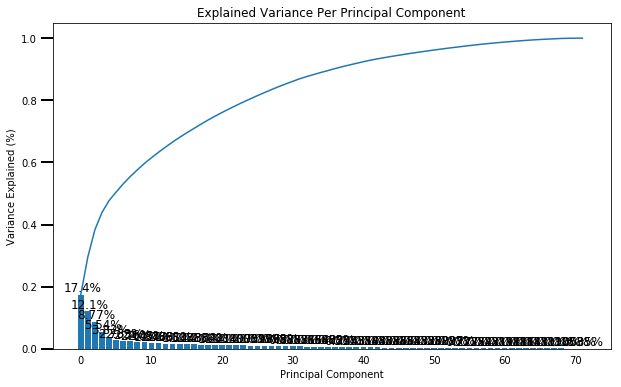

```python
# Investigate the variance accounted for by each principal component.
scree_plot(pca)
```

```python
cumvals = np.cumsum(pca.explained_variance_ratio_*100)
for i in range(0, len(pca.explained_variance_ratio_), 5):
    print(f"With {i+1} components, {cumvals[i]:.2f}% of total variance is achieved")
```

```
With 1 components, 17.45% of total variance is achieved
With 6 components, 50.44% of total variance is achieved
With 11 components, 61.49% of total variance is achieved
With 16 components, 69.52% of total variance is achieved
With 21 components, 76.08% of total variance is achieved
With 26 components, 81.49% of total variance is achieved
With 31 components, 86.11% of total variance is achieved
With 36 components, 89.59% of total variance is achieved
With 41 components, 92.41% of total variance is achieved
With 46 components, 94.50% of total variance is achieved
With 51 components, 96.18% of total variance is achieved
With 56 components, 97.61% of total variance is achieved
With 61 components, 98.75% of total variance is achieved
With 66 components, 99.57% of total variance is achieved
With 71 components, 100.00% of total variance is achieved
```

```python
# Re-apply PCA to the data while selecting for number of components to retain.
pca_26 = PCA(n_components=26)
pca_transformed = pca_26.fit_transform(df_transformed)
```

### Discussion 2.2: Perform Dimensionality Reduction

I will be retaining 26 components. The model is obtaining a cumulative feature variance of 80% with a dimension count of just over a third of the total features. I think of this as 80% success with just under 35% of the information.

### Step 2.3: Interpret Principal Components

Now that we have our transformed principal components, it's a nice idea to check out the weight of each variable on the first few components to see if they can be interpreted in some fashion.

As a reminder, each principal component is a unit vector that points in the direction of highest variance (after accounting for the variance captured by earlier principal components). The further a weight is from zero, the more the principal component is in the direction of the corresponding feature. If two features have large weights of the same sign (both positive or both negative), then increases in one tend expect to be associated with increases in the other. To contrast, features with different signs can be expected to show a negative correlation: increases in one variable should result in a decrease in the other.

- To investigate the features, you should map each weight to their corresponding feature name, then sort the features according to weight. The most interesting features for each principal component, then, will be those at the beginning and end of the sorted list. Use the data dictionary document to help you understand these most prominent features, their relationships, and what a positive or negative value on the principal component might indicate.
- You should investigate and interpret feature associations from the first three principal components in this substep. To help facilitate this, you should write a function that you can call at any time to print the sorted list of feature weights, for the *i*-th principal component. This might come in handy in the next step of the project, when you interpret the tendencies of the discovered clusters.

```python
dimensions = pca_dimensions(df, pca_26)
```

```python
dimensions = dimensions.drop(columns = 'Explained Variance').T

dim1=pd.DataFrame(dimensions.sort_values('Dimension 1', ascending=False)['Dimension 1'])
dim1.head(10)
```

|  | Dimension 1 |
| --- | --- |
| MOBI_REGIO | 0.2298 |
| LP_STATUS_FEIN | 0.2214 |
| KBA05_ANTG1 | 0.2162 |
| PLZ8_ANTG1 | 0.2125 |
| FINANZ_MINIMALIST | 0.2066 |
| KBA05_GBZ | 0.2050 |
| PLZ8_GBZ | 0.1559 |
| KONSUMNAEHE | 0.1545 |
| INNENSTADT | 0.1503 |
| LP_LEBENSPHASE_FEIN | 0.1451 |

```python
# Map weights for the second principal component to corresponding feature names
# and then print the linked values, sorted by weight.
dim2=pd.DataFrame(dimensions.sort_values('Dimension 2', ascending=False)['Dimension 2'])
dim2.head(10)
```

|  | Dimension 2 |
| --- | --- |
| ALTERSKATEGORIE_GROB | 0.2639 |
| SEMIO_ERL | 0.2481 |
| FINANZ_VORSORGER | 0.2239 |
| SEMIO_LUST | 0.1820 |
| RETOURTYP_BK_S | 0.1603 |
| SEMIO_KRIT | 0.1358 |
| SEMIO_KAEM | 0.1250 |
| SHOPPER_TYP | 0.1182 |
| W_KEIT_KIND_HH | 0.1125 |
| FINANZTYP | 0.1068 |

```python
# Map weights for the third principal component to corresponding feature names
# and then print the linked values, sorted by weight.
dim3=pd.DataFrame(dimensions.sort_values('Dimension 3', ascending=False)['Dimension 3'])
dim3.head(10)
```

|  | Dimension 3 |
| --- | --- |
| SEMIO_VERT | 0.3365 |
| SEMIO_SOZ | 0.2511 |
| SEMIO_FAM | 0.2353 |
| SEMIO_KULT | 0.2131 |
| FINANZ_MINIMALIST | 0.1618 |
| RETOURTYP_BK_S | 0.1252 |
| FINANZTYP | 0.1245 |
| FINANZ_VORSORGER | 0.1070 |
| W_KEIT_KIND_HH | 0.0981 |
| ALTERSKATEGORIE_GROB | 0.0963 |

```python
#Function details found under Step 2: Feature Transformation
display_side_by_side(dim1,dim2,dim3, titles=['Dimension1 Weights','Dimension2 Weights','Dimension3 Weights'])
```

Dimension1 Weights

|  | Dimension 1 |
| --- | --- |
| MOBI_REGIO | 0.2298 |
| LP_STATUS_FEIN | 0.2214 |
| KBA05_ANTG1 | 0.2162 |
| PLZ8_ANTG1 | 0.2125 |
| FINANZ_MINIMALIST | 0.2066 |
| KBA05_GBZ | 0.2050 |
| PLZ8_GBZ | 0.1559 |
| KONSUMNAEHE | 0.1545 |
| INNENSTADT | 0.1503 |
| LP_LEBENSPHASE_FEIN | 0.1451 |
| LIFESTYLE | 0.1186 |
| MAIN_AVA | 0.1150 |
| GREEN_AVANTGARDE | 0.1150 |
| BALLRAUM | 0.1138 |
| GEBAEUDETYP_RASTER | 0.1084 |
| ALTERSKATEGORIE_GROB | 0.1074 |
| FINANZ_VORSORGER | 0.1004 |
| ANZ_PERSONEN | 0.0950 |
| LP_FAMILIE_FEIN | 0.0900 |
| SEMIO_LUST | 0.0785 |
| WOHNLAGE | 0.0733 |
| SEMIO_ERL | 0.0705 |
| WOHNDAUER_2008 | 0.0628 |
| FINANZTYP | 0.0547 |
| ONLINE_AFFINITAET | 0.0481 |
| SEMIO_VERT | 0.0327 |
| RETOURTYP_BK_S | 0.0164 |
| ANZ_TITEL | 0.0056 |
| SHOPPER_TYP | 0.0028 |
| SOHO_KZ | 0.0025 |
| E_W | -0.0035 |
| ANREDE_KZ | -0.0074 |
| KBA05_ANTG2 | -0.0113 |
| SEMIO_KRIT | -0.0114 |
| VERS_TYP | -0.0202 |
| SEMIO_DOM | -0.0210 |
| ANZ_HH_TITEL | -0.0281 |
| HEALTH_TYP | -0.0309 |
| SEMIO_SOZ | -0.0359 |
| SEMIO_KAEM | -0.0378 |
| CJT_GESAMTTYP | -0.0404 |
| PLZ8_HHZ | -0.0408 |
| KKK | -0.0420 |
| W_KEIT_KIND_HH | -0.0465 |
| FINANZ_ANLEGER | -0.0572 |
| OST_WEST_KZ | -0.0582 |
| SEMIO_KULT | -0.0599 |
| FINANZ_UNAUFFAELLIGER | -0.0633 |
| GFK_URLAUBERTYP | -0.0647 |
| SEMIO_FAM | -0.0674 |
| GEBAEUDETYP | -0.0689 |
| REGIOTYP | -0.0690 |
| SEMIO_MAT | -0.0739 |
| SEMIO_RAT | -0.0829 |
| SEMIO_TRADV | -0.0860 |
| SEMIO_REL | -0.0917 |
| SEMIO_PFLICHT | -0.0972 |
| RELAT_AB | -0.1214 |
| FINANZ_SPARER | -0.1280 |
| KBA05_ANTG3 | -0.1328 |
| ARBEIT | -0.1332 |
| ZABEOTYP | -0.1364 |
| KBA05_ANTG4 | -0.1414 |
| PLZ8_ANTG2 | -0.1417 |
| FINANZ_HAUSBAUER | -0.1555 |
| EWDICHTE | -0.1780 |
| ORTSGR_KLS9 | -0.1810 |
| WEALTH | -0.1926 |
| HH_EINKOMMEN_SCORE | -0.1942 |
| PLZ8_BAUMAX | -0.2006 |
| PLZ8_ANTG4 | -0.2047 |
| PLZ8_ANTG3 | -0.2119 |

Dimension2 Weights

|  | Dimension 2 |
| --- | --- |
| ALTERSKATEGORIE_GROB | 0.2639 |
| SEMIO_ERL | 0.2481 |
| FINANZ_VORSORGER | 0.2239 |
| SEMIO_LUST | 0.1820 |
| RETOURTYP_BK_S | 0.1603 |
| SEMIO_KRIT | 0.1358 |
| SEMIO_KAEM | 0.1250 |
| SHOPPER_TYP | 0.1182 |
| W_KEIT_KIND_HH | 0.1125 |
| FINANZTYP | 0.1068 |
| ANREDE_KZ | 0.1056 |
| FINANZ_HAUSBAUER | 0.1025 |
| SEMIO_DOM | 0.0838 |
| PLZ8_ANTG3 | 0.0807 |
| EWDICHTE | 0.0784 |
| ORTSGR_KLS9 | 0.0780 |
| PLZ8_ANTG4 | 0.0765 |
| PLZ8_BAUMAX | 0.0716 |
| FINANZ_MINIMALIST | 0.0703 |
| WOHNDAUER_2008 | 0.0586 |
| ARBEIT | 0.0582 |
| WEALTH | 0.0559 |
| RELAT_AB | 0.0543 |
| KBA05_ANTG4 | 0.0540 |
| PLZ8_ANTG2 | 0.0535 |
| KBA05_ANTG3 | 0.0392 |
| HH_EINKOMMEN_SCORE | 0.0348 |
| E_W | 0.0295 |
| OST_WEST_KZ | 0.0282 |
| VERS_TYP | 0.0257 |
| ANZ_HH_TITEL | 0.0250 |
| REGIOTYP | 0.0158 |
| PLZ8_HHZ | 0.0120 |
| GEBAEUDETYP | 0.0102 |
| ANZ_TITEL | 0.0071 |
| LIFESTYLE | 0.0051 |
| KKK | -0.0007 |
| SOHO_KZ | -0.0022 |
| KBA05_ANTG2 | -0.0077 |
| MAIN_AVA | -0.0113 |
| GREEN_AVANTGARDE | -0.0113 |
| ZABEOTYP | -0.0200 |
| GEBAEUDETYP_RASTER | -0.0335 |
| LP_STATUS_FEIN | -0.0356 |
| LP_LEBENSPHASE_FEIN | -0.0372 |
| GFK_URLAUBERTYP | -0.0401 |
| WOHNLAGE | -0.0496 |
| HEALTH_TYP | -0.0512 |
| BALLRAUM | -0.0516 |
| KONSUMNAEHE | -0.0558 |
| PLZ8_GBZ | -0.0611 |
| INNENSTADT | -0.0642 |
| ANZ_PERSONEN | -0.0644 |
| KBA05_ANTG1 | -0.0659 |
| LP_FAMILIE_FEIN | -0.0701 |
| MOBI_REGIO | -0.0720 |
| KBA05_GBZ | -0.0721 |
| PLZ8_ANTG1 | -0.0787 |
| SEMIO_VERT | -0.0818 |
| SEMIO_SOZ | -0.1179 |
| CJT_GESAMTTYP | -0.1222 |
| ONLINE_AFFINITAET | -0.1581 |
| SEMIO_MAT | -0.1639 |
| SEMIO_RAT | -0.1689 |
| FINANZ_ANLEGER | -0.1956 |
| SEMIO_FAM | -0.1981 |
| FINANZ_UNAUFFAELLIGER | -0.2234 |
| SEMIO_TRADV | -0.2340 |
| FINANZ_SPARER | -0.2345 |
| SEMIO_KULT | -0.2364 |
| SEMIO_PFLICHT | -0.2433 |
| SEMIO_REL | -0.2766 |

Dimension3 Weights

|  | Dimension 3 |
| --- | --- |
| SEMIO_VERT | 0.3365 |
| SEMIO_SOZ | 0.2511 |
| SEMIO_FAM | 0.2353 |
| SEMIO_KULT | 0.2131 |
| FINANZ_MINIMALIST | 0.1618 |
| RETOURTYP_BK_S | 0.1252 |
| FINANZTYP | 0.1245 |
| FINANZ_VORSORGER | 0.1070 |
| W_KEIT_KIND_HH | 0.0981 |
| ALTERSKATEGORIE_GROB | 0.0963 |
| SEMIO_LUST | 0.0813 |
| ORTSGR_KLS9 | 0.0605 |
| EWDICHTE | 0.0597 |
| SEMIO_REL | 0.0585 |
| PLZ8_BAUMAX | 0.0580 |
| PLZ8_ANTG4 | 0.0566 |
| PLZ8_ANTG3 | 0.0564 |
| MAIN_AVA | 0.0552 |
| GREEN_AVANTGARDE | 0.0552 |
| ARBEIT | 0.0413 |
| WOHNDAUER_2008 | 0.0377 |
| SEMIO_MAT | 0.0375 |
| RELAT_AB | 0.0371 |
| PLZ8_ANTG2 | 0.0368 |
| KBA05_ANTG4 | 0.0316 |
| WEALTH | 0.0277 |
| VERS_TYP | 0.0266 |
| LP_STATUS_FEIN | 0.0206 |
| OST_WEST_KZ | 0.0192 |
| ANZ_HH_TITEL | 0.0152 |
| ANZ_TITEL | 0.0114 |
| PLZ8_HHZ | 0.0110 |
| KBA05_ANTG3 | 0.0092 |
| GEBAEUDETYP | 0.0087 |
| SOHO_KZ | 0.0004 |
| LP_LEBENSPHASE_FEIN | -0.0010 |
| E_W | -0.0040 |
| REGIOTYP | -0.0071 |
| LIFESTYLE | -0.0097 |
| ANZ_PERSONEN | -0.0104 |
| HEALTH_TYP | -0.0107 |
| KBA05_ANTG2 | -0.0125 |
| KKK | -0.0204 |
| LP_FAMILIE_FEIN | -0.0231 |
| KBA05_ANTG1 | -0.0270 |
| HH_EINKOMMEN_SCORE | -0.0281 |
| GFK_URLAUBERTYP | -0.0297 |
| KBA05_GBZ | -0.0310 |
| WOHNLAGE | -0.0328 |
| MOBI_REGIO | -0.0345 |
| GEBAEUDETYP_RASTER | -0.0361 |
| CJT_GESAMTTYP | -0.0408 |
| PLZ8_GBZ | -0.0434 |
| BALLRAUM | -0.0446 |
| FINANZ_HAUSBAUER | -0.0462 |
| KONSUMNAEHE | -0.0469 |
| INNENSTADT | -0.0543 |
| PLZ8_ANTG1 | -0.0563 |
| ONLINE_AFFINITAET | -0.0633 |
| ZABEOTYP | -0.0691 |
| SEMIO_PFLICHT | -0.0911 |
| SEMIO_TRADV | -0.0998 |
| FINANZ_UNAUFFAELLIGER | -0.1077 |
| FINANZ_SPARER | -0.1131 |
| SHOPPER_TYP | -0.1206 |
| SEMIO_ERL | -0.1537 |
| FINANZ_ANLEGER | -0.1971 |
| SEMIO_RAT | -0.2261 |
| SEMIO_KRIT | -0.2559 |
| SEMIO_DOM | -0.3002 |
| SEMIO_KAEM | -0.3234 |
| ANREDE_KZ | -0.3561 |

### Discussion 2.3: Interpret Principal Components

I find it interesting how the SEMIO_--- have such an impact on these top 3 dimensions. There are a few that are highlyweighted and others negatively weighted. Reviewing the Data_dictionary, these are related to personality typologies of an individual (cultual, religious, family-minded...).

Each dimension has a reference to finance in the top 5 features.

## Step 3: Clustering

### Step 3.1: Apply Clustering to General Population

You've assessed and cleaned the demographics data, then scaled and transformed them. Now, it's time to see how the data clusters in the principal components space. In this substep, you will apply k-means clustering to the dataset and use the average within-cluster distances from each point to their assigned cluster's centroid to decide on a number of clusters to keep.

- Use sklearn's KMeans class to perform k-means clustering on the PCA-transformed data.
- Then, compute the average difference from each point to its assigned cluster's center. **Hint**: The KMeans object's `.score()` method might be useful here, but note that in sklearn, scores tend to be defined so that larger is better. Try applying it to a small, toy dataset, or use an internet search to help your understanding.
- Perform the above two steps for a number of different cluster counts. You can then see how the average distance decreases with an increasing number of clusters. However, each additional cluster provides a smaller net benefit. Use this fact to select a final number of clusters in which to group the data. **Warning**: because of the large size of the dataset, it can take a long time for the algorithm to resolve. The more clusters to fit, the longer the algorithm will take. You should test for cluster counts through at least 10 clusters to get the full picture, but you shouldn't need to test for a number of clusters above about 30.
- Once you've selected a final number of clusters to use, re-fit a KMeans instance to perform the clustering operation. Make sure that you also obtain the cluster assignments for the general demographics data, since you'll be using them in the final Step 3.3.

```
1
2
3
4
5
6
7
8
9
10
11
12
13
14
15
16
17
18
19
20
```

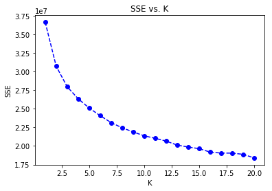

```python
# Over a number of different cluster counts...
scores = []
centers = list(range(1,21))

# run k-means clustering on the data and...
for center in centers:
    scores.append(get_kmeans_score(pca_transformed, center))
    print(center) #Since this is a slower running process, I print as it goes to see if it's still moving or stalled.

# compute the average within-cluster distances.

plt.plot(centers, scores, linestyle='--', marker='o', color='b');
plt.xlabel('K');
plt.ylabel('SSE');
plt.title('SSE vs. K');
```

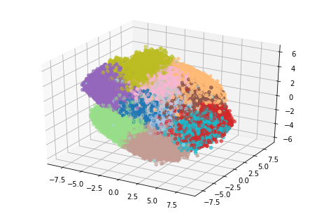

```python
# Re-fit the k-means model with the selected number of clusters and obtain
# cluster predictions for the general population demographics data.
kmeans_13 = KMeans(13)
Pop_predict = kmeans_13.fit_predict(pca_transformed)
plot_data(pca_transformed, Pop_predict)
```

### Discussion 3.1: Apply Clustering to General Population

Reviewing the linear line plot, it looks like the line stays a flatline from 13 to 14 centers. It looks to drop again at 15 and 16, then consistant again for 17 and continues with this pattern. Since 14 is the first flatline, 13 is the centers I'll be proceeding with.

### Step 3.2: Apply All Steps to the Customer Data

Now that you have clusters and cluster centers for the general population, it's time to see how the customer data maps on to those clusters. Take care to not confuse this for re-fitting all of the models to the customer data. Instead, you're going to use the fits from the general population to clean, transform, and cluster the customer data. In the last step of the project, you will interpret how the general population fits apply to the customer data.

- Don't forget when loading in the customers data, that it is semicolon (`;`) delimited.
- Apply the same feature wrangling, selection, and engineering steps to the customer demographics using the `clean_data()` function you created earlier. (You can assume that the customer demographics data has similar meaning behind missing data patterns as the general demographics data.)
- Use the sklearn objects from the general demographics data, and apply their transformations to the customers data. That is, you should not be using a `.fit()` or `.fit_transform()` method to re-fit the old objects, nor should you be creating new sklearn objects! Carry the data through the feature scaling, PCA, and clustering steps, obtaining cluster assignments for all of the data in the customer demographics data.

Cells needed for successful processing: Cell One Cleaning Function Feature Transformation Functions Feature Transformation Cluster Functions Cluster

```python
# Load in the customer demographics data.
customers = pd.read_csv('Udacity_CUSTOMERS_Subset.csv', sep=';')
```

```python
# Apply preprocessing, feature transformation, and clustering from the general
# demographics onto the customer data, obtaining cluster predictions for the
# customer demographics data.

cust_clean = clean_data(customers)
cust_scaled = scaler.transform(cust_clean)
print("scaled")
cust_transformed = pca_26.transform(cust_scaled)
print("transformed")
cust_predict = kmeans_13.predict(cust_transformed)
print("predicted")
```

```
Number of rows dropped: 75857
(115795, 72)
scaled
transformed
predicted
```

```python
cust_clean.describe()
```

|  | ALTERSKATEGORIE_GROB | ANREDE_KZ | CJT_GESAMTTYP | FINANZ_MINIMALIST | FINANZ_SPARER | FINANZ_VORSORGER | FINANZ_ANLEGER | FINANZ_UNAUFFAELLIGER | FINANZ_HAUSBAUER | FINANZTYP | ... | PLZ8_BAUMAX | PLZ8_HHZ | PLZ8_GBZ | ARBEIT | ORTSGR_KLS9 | RELAT_AB | MAIN_AVA | E_W | WEALTH | LIFESTYLE |
| --- | --- | --- | --- | --- | --- | --- | --- | --- | --- | --- | --- | --- | --- | --- | --- | --- | --- | --- | --- | --- | --- |
| count | 115795.000000 | 115795.000000 | 115795.000000 | 115795.000000 | 115795.000000 | 115795.000000 | 115795.000000 | 115795.000000 | 115795.000000 | 115795.000000 | ... | 115795.000000 | 115795.000000 | 115795.000000 | 115795.000000 | 115795.000000 | 115795.000000 | 115795.000000 | 115795.000000 | 115795.000000 | 115795.000000 |
| mean | 3.529323 | 1.323563 | 3.013058 | 4.285470 | 1.395578 | 4.596399 | 1.551449 | 1.795354 | 2.769714 | 4.281765 | ... | 1.561700 | 3.631832 | 3.611538 | 2.836867 | 5.163219 | 2.921741 | 0.531448 | 1.779006 | 2.605855 | 3.396485 |
| std | 0.677047 | 0.467838 | 1.497337 | 1.003145 | 0.797860 | 0.819962 | 0.959327 | 0.928975 | 1.291052 | 1.702815 | ... | 1.188352 | 0.924963 | 1.006792 | 1.005531 | 2.158870 | 1.420206 | 0.499012 | 0.448852 | 1.408091 | 1.336904 |
| min | 1.000000 | 1.000000 | 1.000000 | 1.000000 | 1.000000 | 1.000000 | 1.000000 | 1.000000 | 1.000000 | 1.000000 | ... | 1.000000 | 1.000000 | 1.000000 | 1.000000 | 1.000000 | 1.000000 | 0.000000 | 0.000000 | 1.000000 | 1.000000 |
| 25% | 3.000000 | 1.000000 | 2.000000 | 4.000000 | 1.000000 | 4.000000 | 1.000000 | 1.000000 | 2.000000 | 2.000000 | ... | 1.000000 | 3.000000 | 3.000000 | 2.000000 | 4.000000 | 2.000000 | 0.000000 | 2.000000 | 1.000000 | 3.000000 |
| 50% | 4.000000 | 1.000000 | 3.000000 | 5.000000 | 1.000000 | 5.000000 | 1.000000 | 2.000000 | 2.000000 | 5.000000 | ... | 1.000000 | 3.000000 | 4.000000 | 3.000000 | 5.000000 | 3.000000 | 1.000000 | 2.000000 | 2.000000 | 4.000000 |
| 75% | 4.000000 | 2.000000 | 4.000000 | 5.000000 | 2.000000 | 5.000000 | 2.000000 | 2.000000 | 4.000000 | 6.000000 | ... | 1.000000 | 4.000000 | 4.000000 | 4.000000 | 7.000000 | 4.000000 | 1.000000 | 2.000000 | 4.000000 | 4.000000 |
| max | 4.000000 | 2.000000 | 6.000000 | 5.000000 | 5.000000 | 5.000000 | 5.000000 | 5.000000 | 5.000000 | 6.000000 | ... | 5.000000 | 5.000000 | 5.000000 | 5.000000 | 9.000000 | 5.000000 | 1.000000 | 2.000000 | 5.000000 | 5.000000 |

8 rows × 72 columns

### Step 3.3: Compare Customer Data to Demographics Data

At this point, you have clustered data based on demographics of the general population of Germany, and seen how the customer data for a mail-order sales company maps onto those demographic clusters. In this final substep, you will compare the two cluster distributions to see where the strongest customer base for the company is.

Consider the proportion of persons in each cluster for the general population, and the proportions for the customers. If we think the company's customer base to be universal, then the cluster assignment proportions should be fairly similar between the two. If there are only particular segments of the population that are interested in the company's products, then we should see a mismatch from one to the other. If there is a higher proportion of persons in a cluster for the customer data compared to the general population (e.g. 5% of persons are assigned to a cluster for the general population, but 15% of the customer data is closest to that cluster's centroid) then that suggests the people in that cluster to be a target audience for the company. On the other hand, the proportion of the data in a cluster being larger in the general population than the customer data (e.g. only 2% of customers closest to a population centroid that captures 6% of the data) suggests that group of persons to be outside of the target demographics.

Take a look at the following points in this step:

- Compute the proportion of data points in each cluster for the general population and the customer data. Visualizations will be useful here: both for the individual dataset proportions, but also to visualize the ratios in cluster representation between groups. Seaborn's [`countplot()`](https://seaborn.pydata.org/generated/seaborn.countplot.html) or [`barplot()`](https://seaborn.pydata.org/generated/seaborn.barplot.html) function could be handy.
  - Recall the analysis you performed in step 1.1.3 of the project, where you separated out certain data points from the dataset if they had more than a specified threshold of missing values. If you found that this group was qualitatively different from the main bulk of the data, you should treat this as an additional data cluster in this analysis. Make sure that you account for the number of data points in this subset, for both the general population and customer datasets, when making your computations!
- Which cluster or clusters are overrepresented in the customer dataset compared to the general population? Select at least one such cluster and infer what kind of people might be represented by that cluster. Use the principal component interpretations from step 2.3 or look at additional components to help you make this inference. Alternatively, you can use the `.inverse_transform()` method of the PCA and StandardScaler objects to transform centroids back to the original data space and interpret the retrieved values directly.
- Perform a similar investigation for the underrepresented clusters. Which cluster or clusters are underrepresented in the customer dataset compared to the general population, and what kinds of people are typified by these clusters?

```
Text(0.5,1,'Population Clusters')
```

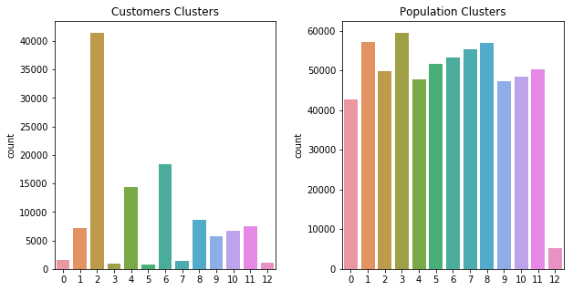

```python
# Compare the proportion of data in each cluster for the customer data to the
# proportion of data in each cluster for the general population.
figure, axs = plt.subplots(nrows=1, ncols=2, figsize = (10,5))
figure.subplots_adjust(hspace = 1, wspace=.3)

sns.countplot(cust_predict, ax=axs[0])
axs[0].set_title('Customers Clusters')
sns.countplot(Pop_predict, ax=axs[1])
axs[1].set_title('Population Clusters')
```

```python
#Proportions(stat) of Countplot wasn't released until version 0.13.0
sns.__version__
```

```
'0.8.1'
```

```
Text(0.5,1,'Presented Difference (Cust-Pop)')
```

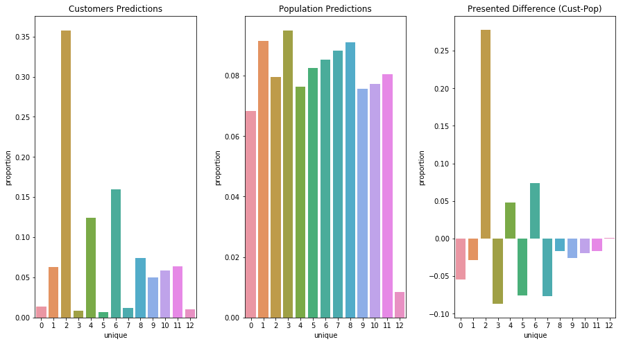

```python
#Since Proportions isn't in countplot, I made barplot work.
def predict_df(predicted):
    unique, counts = np.unique(predicted, return_counts=True)
    proportion=[]
    for count in counts:
        x = count/len(predicted)
        proportion.append(x)
    todf = {'unique': unique, 'counts':counts, 'proportion': proportion}
    df = pd.DataFrame(todf)

    return df

cust_df = predict_df(cust_predict)
pop_df = predict_df(Pop_predict)

figure, axs = plt.subplots(nrows=1, ncols=3, figsize = (15,8))
figure.subplots_adjust(hspace = 1, wspace=.3)

sns.barplot(data=cust_df, x=cust_df.unique, y=cust_df.proportion, ax=axs[0])
axs[0].set_title('Customers Predictions')
sns.barplot(data=pop_df, x=pop_df.unique, y=pop_df.proportion, ax=axs[1])
axs[1].set_title('Population Predictions')
sns.barplot(data=pop_df, x=pop_df.unique, y=(cust_df.proportion - pop_df.proportion), ax=axs[2])
axs[2].set_title('Presented Difference (Cust-Pop)')
```

```python
Cluster = scaler.inverse_transform(pca_26.inverse_transform(kmeans_13.cluster_centers_))
Clusters = pd.DataFrame(Cluster)
Clusters.columns = cust_clean.columns
Clusters.index = ['Cluster_{}'.format(i) for i in range(0,13)]
Clusters = Clusters.T
```

```python
# What kinds of people are part of a cluster that is overrepresented in the
# customer data compared to the general population?
# Cluster 2 is overrepresented in the Customer Population

Clusters.Cluster_2.sort_values(ascending=False).head(10)
```

```
LP_LEBENSPHASE_FEIN    25.237350
LP_STATUS_FEIN          8.942697
WOHNDAUER_2008          8.530644
GFK_URLAUBERTYP         6.468932
SEMIO_VERT              6.191276
LP_FAMILIE_FEIN         5.611562
ORTSGR_KLS9             5.454527
SEMIO_SOZ               5.369449
SEMIO_LUST              5.246148
SEMIO_KULT              4.891129
Name: Cluster_2, dtype: float64
```

#### Overrepresented Cluster #2

The overrepresented group in the mail-order company are:

- Have a life stage of “Average earning Families” (LP_LEBENSPHASE_FEIN 25)
- Who own their homes (LP_STATUS_FEIN 8) and have owned homes for the last 7-10 years (WOHNDAUER_2008 8).
- Tend to be hikers (GFK_URLAUBERTYP 6)
- Slightly dreamful(SEMIO_VERT 6), but more Cultural minded (SEMIO_KULT 4)
- Most likely a single parent of a teenager(LP_FAMILIE_FEIN 5)
- Live in a community of 20,000-50,000 people (ORTSGR_KLS9 5).

```python
# What kinds of people are part of a cluster that is underrepresented in the
# customer data compared to the general population?
# 3 is the most underrepresented in the Customer data than the general Population
Clusters.Cluster_3.sort_values(ascending=False).head(10)
```

```
LP_LEBENSPHASE_FEIN    9.827778
GFK_URLAUBERTYP        8.777664
WOHNDAUER_2008         7.200700
ORTSGR_KLS9            6.949098
SEMIO_RAT              6.529779
SEMIO_PFLICHT          6.519288
SEMIO_DOM              6.315443
SEMIO_KAEM             6.259707
SEMIO_TRADV            6.078208
HH_EINKOMMEN_SCORE     5.652607
Name: Cluster_3, dtype: float64
```

The underrepresented group in the mail-order company are:

- Are in a lifestyle stage of “Single independent people” (LP_LEBENSPHASE_FEIN 9)
- Do not generally vacation near homeland (GFK_URLAUBERTYP 8)
- Have a length of residence 6-7 years (WOHNDAUER_2008 7)
- Live in a community of 50,000-100,000 people (ORTSGR_KLS9 6)
- Based on the Personality typology, they are not rational, dutiful, dominate, combative, or traditionalists. (RAT 6, PFLICHT 6, DOM 6, KAEM 6, TRADV 6)
- Have a lower household income (HH_EINKOMMEN_SCORE 5)

### Discussion 3.3: Compare Customer Data to Demographics Data

Marketing should focus single parents with average or better incomes, who has owned their own homes for 7 or more years, and children are teenager or more. The focus should be on more outdoorsy adventurous people in communities with a population less than 50,000.

> Congratulations on making it this far in the project! Before you finish, make sure to check through the entire notebook from top to bottom to make sure that your analysis follows a logical flow and all of your findings are documented in **Discussion** cells. Once you've checked over all of your work, you should export the notebook as an HTML document to submit for evaluation. You can do this from the menu, navigating to **File -> Download as -> HTML (.html)**. You will submit both that document and this notebook for your project submission.

```python
def FeatureDescription(features):
    with open('Data_Dictionary.md', 'r') as DataFile:
        text = DataFile.read()
        for feature in features:
            start = text.find(feature)
            end = text.find('###', start)
            DataDescribe = text[start:end]
            print(f'\033[1m For {feature}:\033[0m {DataDescribe}')
```